# Nursing Home Staffing Analysis

Alavi Khan

12/3/2021

# Nursing Home Staffing Data Analysis

## Background

The Nursing Home Staffing Data was collected to support BuzzFeed News article on nursing home facilities, published April 21, 2020.Article title was “It’s Only Going To Get Worse”: Residents Of Nursing Homes, No Longer Being Inspected, Face New Perils. The Article Analysis attempts to provide understanding of current status of Nursing Home Staffing and examine the conditions are adequate to support nursing home residents and ill people who rely on nursing homes for their ailments and recovery.

The inspections was conducted by inspectors with the permission from the Centers for Medicare and Medicaid Services (CMS).The inspectors visited 96 homes from March 23 through April 10 and found that nearly 1 in 5 not properly using protective equipment such as gloves or masks.

The combination of aging residents, inadequate staffing, and the inability of caretakers to treat the rush of sick patients has created environments for the virus to take a dramatic toll on long-term care homes.

The article sheds light on the poor conditions and lack of adherence to standards set by government agency which can result to oversights and cause danger to the lives of the residents.

### Motivation to work with the Dataset

To understand the Nursing Home staff data from analyst point of view. To understand the standards and regulation required to improve the overall conditions nursing home. The data set collected is very recent and provides actual insights related to nursing homes.

## About the Dataset

Nursing Home Staffing data is one of three data set collected during the inspection. The Dataset has Staffing levels recorded by CMS.It is observational study.

Dataset has 89 variables/attributes and more than 15000 records/observation.Out of the whole 57 attributes are numeric 22 attributes are categorical in initial inspection.Attributes have names describing their values.

Brief about the attributes - Many attributes provide details about the location, Rating received based on specific criteria, rating provided during inspection (attributes with have rating cycle keyword in the start), Specific score or rating given by CMS, amount of hours spent by particular staffing type on the premises in a day, Fine or charges based on past activities, foot note received by the nursing home , dates associated with processing and indicators providing details such as special focus.

Attributes were captured using R command col-names.

Attributes which provide providers details : “federal_provider_number”(Unique Identifier) , “provider_name” , “provider_address” , “provider_city”(City), “provider_state” , “provider_zip_code” ,“provider_phone_number”, “provider_ssa_county”, “provider_county_name”, “provider_type”,“provider_resides_in_hospital”

Attributes which provides details about Nursing home: “ownership_type”, “number_of_certified_beds”, “number_of_residents_in_certified_beds”, “legal_business_name”, “date_first_approved_to_provide_medicare_and_medicaid_services”, “continuing_care_retirement_community”, “cited_for_abuse”, “most_recent_health_inspection_more_than_2_years_ago”, “provider_changed_ownership_in_last_12_months”, “with_a_resident_and_family_council”, “automatic_sprinkler_systems_in_all_required_areas”, “overall_rating”, “health_inspection_rating”, “qm_rating”, “long_stay_qm_rating”, “short_stay_qm_rating_footnote”, “staffing_rating”, “rn_staffing_rating”, “reported_cna_staffing_hours_per_resident_per_day”, “reported_lpn_staffing_hours_per_resident_per_day”, “reported_rn_staffing_hours_per_resident_per_day”, “reported_licensed_staffing_hours_per_resident_per_day”, “reported_total_nurse_staffing_hours_per_resident_per_day”, “reported_physical_therapist_staffing_hours_per_resident_per_day”, “casemix_cna_staffing_hours_per_resident_per_day”, “casemix_lpn_staffing_hours_per_resident_per_day”, “casemix_rn_staffing_hours_per_resident_per_day”, “casemix_total_nurse_staffing_hours_per_resident_per_day”, “adjusted_cna_staffing_hours_per_resident_per_day”, “adjusted_lpn_staffing_hours_per_resident_per_day”, “adjusted_rn_staffing_hours_per_resident_per_day”, “adjusted_total_nurse_staffing_hours_per_resident_per_day”, “total_weighted_health_survey_score”, “number_of_facility_reported_incidents”, number_of_substantiated_complaints”, “number_of_fines”, “total_amount_of_fines_in_dollars”, “number_of_payment_denials”, “total_number_of_penalties”, “processing_date”, “overall_rating_footnote”, “health_inspection_rating_footnote”, “qm_rating_footnote”, “long_stay_qm_rating_footnote”, “staffing_rating_footnote”, “rn_staffing_rating_footnote”, “reported_staffing_footnote”, “physical_therapist_staffing_footnote”, “location”, “X..computed_region_f3tr_pr43”, “X..computed_region_nwen_78xc”, “X..computed_region_csmy_5jwy”, “short_stay_qm_rating”, “special_focus_status”

Following attributes were recorded related to rating_cycle which are listed as :“rating_cycle_1_number_of_complaint_health_deficiencies”, “rating_cycle_1_health_deficiency_score”, “rating_cycle_1_number_of_health_revisits”, “rating_cycle_1_health_revisit_score”, “rating_cycle_1_total_health_score”, “rating_cycle_2_standard_health_survey_date”, “rating_cycle_2_total_number_of_health_deficiencies”, “rating_cycle_2_number_of_standard_health_deficiencies”, “rating_cycle_2, _number_of_complaint_health_deficiencies”, “rating_cycle_2_health_deficiency_score”, “rating_cycle_2_number_of_health_revisits”, “rating_cycle_2_health_revisit_score”, “rating_cycle_2_total_health_score”, “rating_cycle_3_standard_health_survey_date”, “rating_cycle_3_total_number_of_health_deficiencies”, “rating_cycle_3_number_of_standard_health_deficiencies”, “rating_cycle_3_number_of_complaint_health_deficiencies”, “rating_cycle_3_number_of_health_revisits”, “rating_cycle_3_health_deficiency_score”, “rating_cycle_3_health_revisit_score”, “rating_cycle_3_total_health_score”

Note: No Data dictionary was available in the github repository of the source to describe the above attributes.

## Goal and Questions

1. What type of distribution is present in the attributes ?
2. Is there any relation between the attributes or they are all independent to each other?
3. Can we summarize the nurse home staffing capabilities of the records collected?
4. Can we classify Nurse Home based on staffing capabilities ?
5. Which attributes of Nurse Home Staffing are significant factor in determining Nursing home staffing quality?

## Analysis

### Loading Pre requisite Libraries

```r
library(tidyverse)
#Loading library ggplot and MASS for usage
library(ggplot2)
```

For initial analysis 15 variables/attributes were considered, based on description and attribute names.

### Loading Dataset Nursing home data

```r
data_staffing<- as_tibble(read.csv("staffing.csv"))

data_staffing <-dplyr::select(data_staffing,federal_provider_number,provider_name,provider_state,provider_zip_code,provider_phone_number,provider_ssa_county,number_of_certified_beds,number_of_residents_in_certified_beds,overall_rating,health_inspection_rating,qm_rating,number_of_payment_denials,total_number_of_penalties,overall_rating_footnote,health_inspection_rating_footnote)
```

### Data Summary

```r
head(data_staffing)
```

```
## # A tibble: 6 × 15
##   federal_prov…¹ provi…² provi…³ provi…⁴ provi…⁵ provi…⁶ numbe…⁷ numbe…⁸ overa…⁹
##   <chr>          <chr>   <chr>     <int>   <dbl>   <int>   <int>   <dbl>   <int>
## 1 015407         HEALTH… AL        35953  2.06e9     570      53    45         3
## 2 035297         SURPRI… AZ        85374  6.24e9      60     100    NA        NA
## 3 065264         WALBRI… CO        81641  9.71e9     510      30    27.5       3
## 4 075322         ESSEX … CT         6426  8.61e9      30      45    40.4       5
## 5 075346         ROSE H… CT         6759  8.61e9      20      25    NA         2
## 6 105393         BEAR C… FL        34667  7.28e9     500     120   108.        5
## # … with 6 more variables: health_inspection_rating <int>, qm_rating <int>,
## #   number_of_payment_denials <int>, total_number_of_penalties <int>,
## #   overall_rating_footnote <int>, health_inspection_rating_footnote <int>, and
## #   abbreviated variable names ¹federal_provider_number, ²provider_name,
## #   ³provider_state, ⁴provider_zip_code, ⁵provider_phone_number,
## #   ⁶provider_ssa_county, ⁷number_of_certified_beds,
## #   ⁸number_of_residents_in_certified_beds, ⁹overall_rating
```

```r
dim(data_staffing)
```

```
## [1] 15446    15
```

```r
##colnames(data_staffing)
```

15 variable/attributes are present and 15446 observations.

Attributes are mix of categorical and numerical types.

We can observe attribute types at first glance is 12 numerical and 3 categorical.

#### Understanding Distribution of Numerical Type attributes

```r
##sapply(data_staffing, class,USE.NAMES = TRUE)
data_staffing %>% dplyr::select(where(is.numeric)) %>% select(!(provider_zip_code:provider_phone_number:provider_ssa_county)) %>% summary()
```

```
##  number_of_certified_beds number_of_residents_in_certified_beds overall_rating
##  Min.   :   1.0           Min.   :  1.00                        Min.   :1.000
##  1st Qu.:  64.0           1st Qu.: 51.00                        1st Qu.:2.000
##  Median :  99.0           Median : 78.10                        Median :3.000
##  Mean   : 106.2           Mean   : 85.88                        Mean   :3.129
##  3rd Qu.: 127.0           3rd Qu.:107.60                        3rd Qu.:4.000
##  Max.   :1389.0           Max.   :753.10                        Max.   :5.000
##                           NA's   :86                            NA's   :178
##  health_inspection_rating   qm_rating     number_of_payment_denials
##  Min.   :1.00             Min.   :1.000   Min.   :0.0000
##  1st Qu.:2.00             1st Qu.:3.000   1st Qu.:0.0000
##  Median :3.00             Median :4.000   Median :0.0000
##  Mean   :2.81             Mean   :3.633   Mean   :0.1068
##  3rd Qu.:4.00             3rd Qu.:5.000   3rd Qu.:0.0000
##  Max.   :5.00             Max.   :5.000   Max.   :4.0000
##  NA's   :178              NA's   :196
##  total_number_of_penalties overall_rating_footnote
##  Min.   :0.0000            Min.   : 1.000
##  1st Qu.:0.0000            1st Qu.: 1.000
##  Median :0.0000            Median : 1.000
##  Mean   :0.5704            Mean   : 9.118
##  3rd Qu.:1.0000            3rd Qu.:18.000
##  Max.   :9.0000            Max.   :18.000
##                            NA's   :15268
##  health_inspection_rating_footnote
##  Min.   : 1.000
##  1st Qu.: 1.000
##  Median : 1.000
##  Mean   : 9.118
##  3rd Qu.:18.000
##  Max.   :18.000
##  NA's   :15268
```

We can observe Median and Mean are having different magnitude for different attributes, indicating data distribution of has skewness. There are missing data in many attributes and the amount of missing data is Varying. Some of the variable distribution is sparse.

No data clean up is implemented. No imputation is done. In attributes overall rating footnote and health inspection rating footnote number of missing data is more than 70% of the data.Data can termed as extremely sparse.

#### Mode for numerical variable

```r
mode <- function(x){

  which.max(tabulate(x))
}

data_staffing %>% dplyr::select(where(is.numeric)) %>% summarise(across(c(overall_rating_footnote,health_inspection_rating_footnote,total_number_of_penalties,number_of_residents_in_certified_beds,number_of_certified_beds,number_of_certified_beds,health_inspection_rating,number_of_payment_denials,qm_rating,overall_rating),mode))
```

```
## # A tibble: 1 × 9
##   overall_rati…¹ healt…² total…³ numbe…⁴ numbe…⁵ healt…⁶ numbe…⁷ qm_ra…⁸ overa…⁹
##            <int>   <int>   <int>   <int>   <int>   <int>   <int>   <int>   <int>
## 1              1       1       1      54     120       2       1       5       5
## # … with abbreviated variable names ¹overall_rating_footnote,
## #   ²health_inspection_rating_footnote, ³total_number_of_penalties,
## #   ⁴number_of_residents_in_certified_beds, ⁵number_of_certified_beds,
## #   ⁶health_inspection_rating, ⁷number_of_payment_denials, ⁸qm_rating,
## #   ⁹overall_rating
```

```r
#mode(overall_rating_footnote)
```

### Outlier Analysis

```r
data_staffing_num <- data_staffing %>% dplyr::select(where(is.numeric)) %>% select(!(provider_zip_code:provider_phone_number:provider_ssa_county))
```

```r
counter <- 0
for (ind_col in colnames(data_staffing_num)){
  counter <- counter+ 1
  if (counter>2){
    break
  }
    range= range(data_staffing_num[[ind_col]], na.rm = TRUE)


  new_width=(range[2]- range[1])*8/100
  print(ind_col)
  print(mutate(data_staffing_num,bin_group =cut_width(data_staffing_num[[ind_col]],width=new_width))%>% count(bin_group))



}
```

```
## [1] "number_of_certified_beds"
## # A tibble: 10 × 2
##    bin_group              n
##    <fct>              <int>
##  1 [-55.5,55.5]        2548
##  2 (55.5,167]         11128
##  3 (167,278]           1500
##  4 (278,389]            202
##  5 (389,500]             38
##  6 (500,611]             18
##  7 (611,722]              6
##  8 (722,833]              3
##  9 (833,944]              2
## 10 (1.39e+03,1.5e+03]     1
## [1] "number_of_residents_in_certified_beds"
```

[output cut: 18 more lines]

We can observe Positive Skewness in most of numerical data.”health_inspection_rating_footnote” attribute has data aggregated in two places only.Indicating discrete two groups based on that particular attribute.

### Visualization to identify outliers

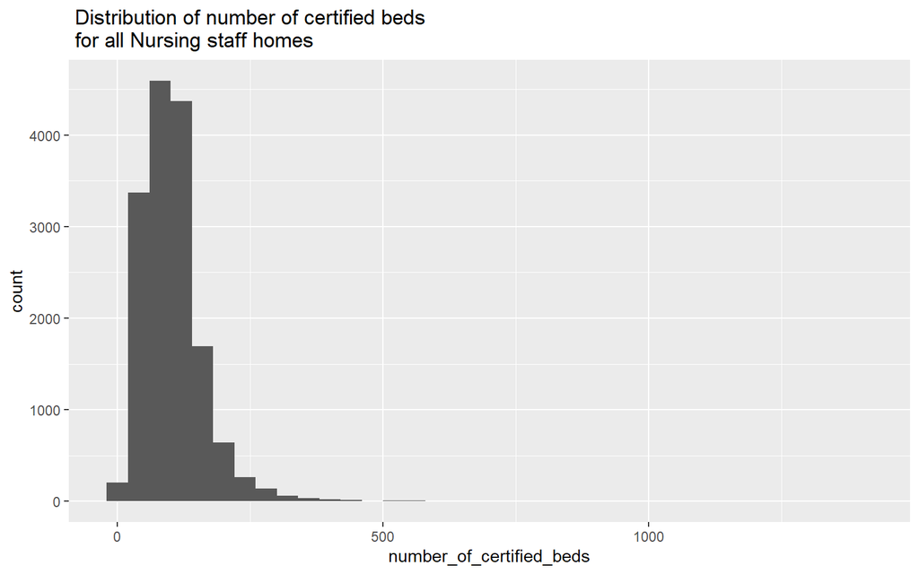

```r
ggplot(data= data_staffing_num)+
  geom_histogram(mapping = aes(x=number_of_certified_beds),binwidth=40,na.rm=TRUE)+ggtitle(" Distribution of number of certified beds\n for all Nursing staff homes ")
```

Positively Skewed graph. We can consider few points in tail as outlier.No points which stands out considering both group bins and graph.

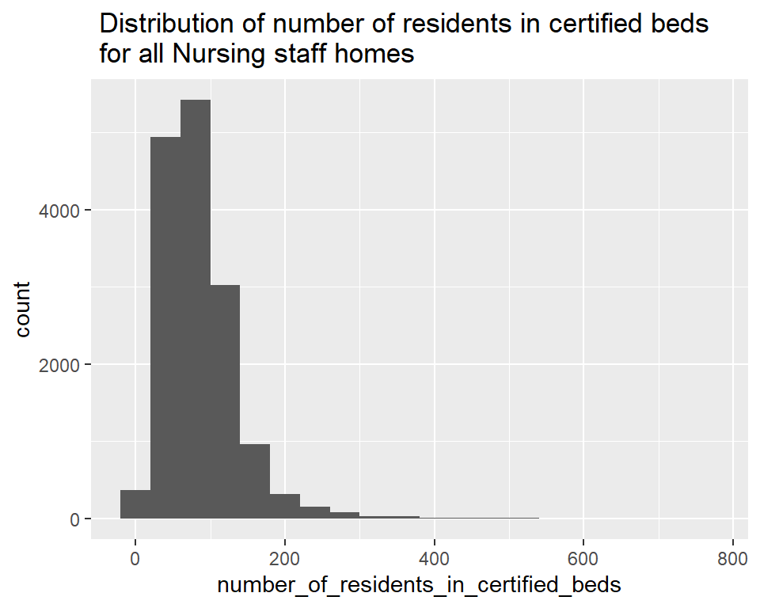

```r
ggplot(data= data_staffing_num)+
  geom_histogram(mapping = aes(x=number_of_residents_in_certified_beds),binwidth=40,na.rm=TRUE)+
  ggtitle(" Distribution of number of residents in certified beds\n for all Nursing staff homes ")
```

Positively Skewed graph. We can consider few points in tail as outlier. No points which stands out considering both group bins and graph.

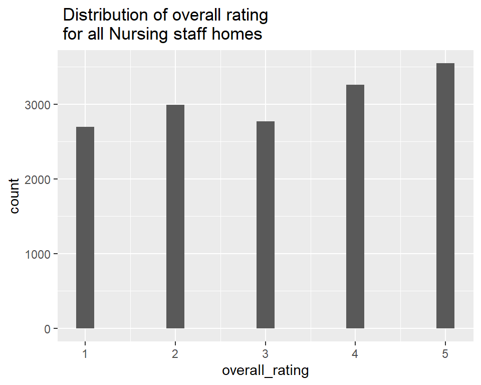

```r
ggplot(data= data_staffing_num)+
  geom_histogram(mapping = aes(x=overall_rating),binwidth=0.2,na.rm=TRUE)+
  ggtitle(" Distribution of overall rating\n for all Nursing staff homes ")
```

Discrete points are present and values are scaterred evenly.Bi-variate analysis can be done to further understand attributes impact.

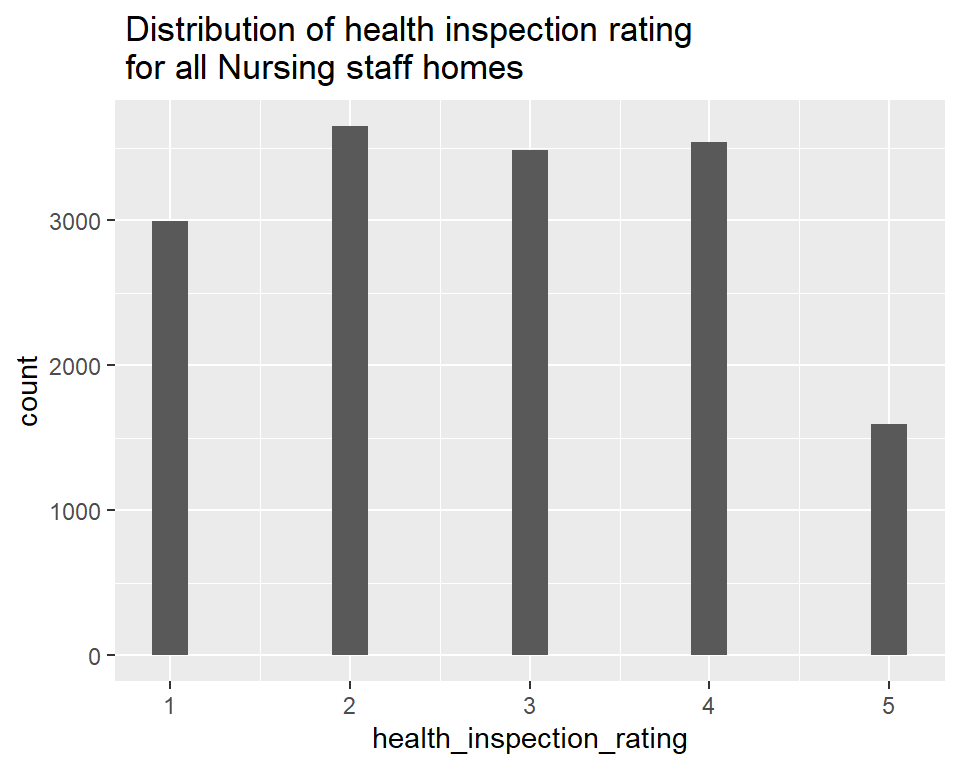

```r
ggplot(data= data_staffing_num)+
  geom_histogram(mapping = aes(x=health_inspection_rating),binwidth=0.2,na.rm=TRUE)+
  ggtitle(" Distribution of health inspection rating\n for all Nursing staff homes ")
```

Discrete points are present and values are scaterred evenly.Bi-variate analysis can be done to further understand attributes impact.

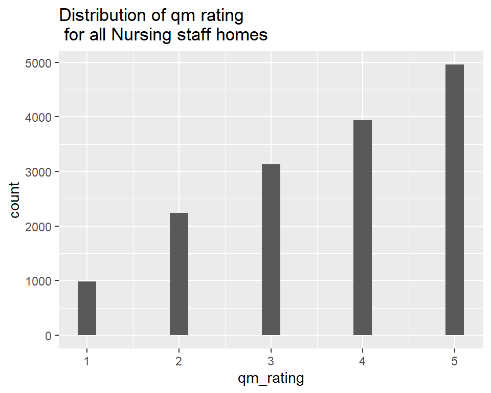

```r
ggplot(data= data_staffing_num)+
  geom_histogram(mapping = aes(x=qm_rating),binwidth=0.2,na.rm=TRUE)+
  ggtitle("Distribution of qm rating\n for all Nursing staff homes ")
```

Discrete points are present and values are scattered evenly.Bi-variate analysis can be done to further understand attributes impact.We can see increasing trend which can be further analysed to understand impact of the rating.

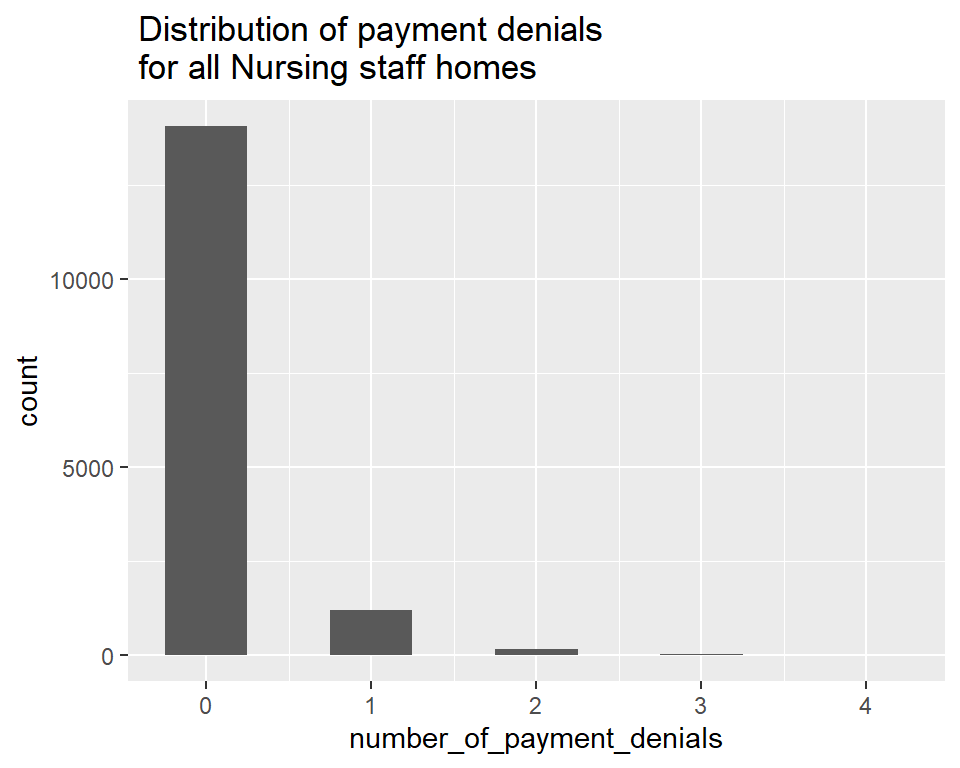

```r
ggplot(data= data_staffing_num)+
  geom_histogram(mapping = aes(x=number_of_payment_denials),binwidth=0.5,na.rm=TRUE)+
  ggtitle(" Distribution of payment denials \n for all Nursing staff homes ")
```

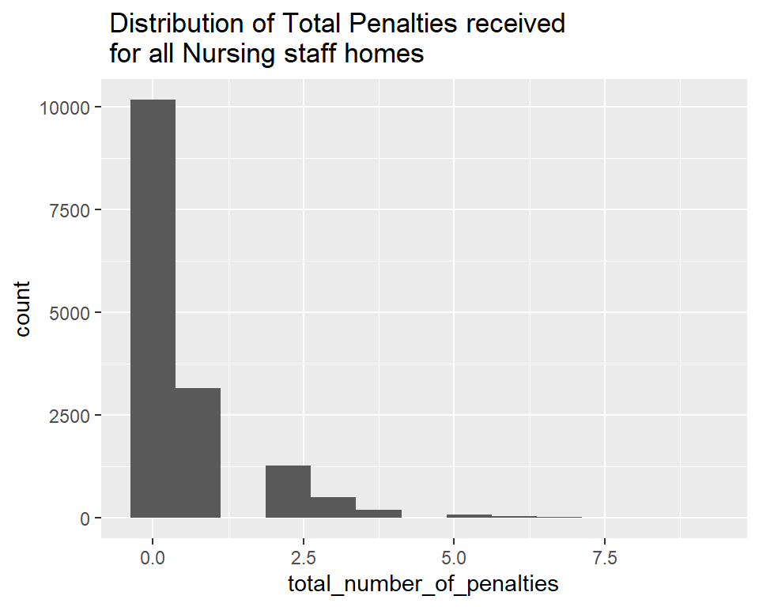

```r
ggplot(data= data_staffing_num)+
  geom_histogram(mapping = aes(x=total_number_of_penalties),binwidth=0.75,na.rm=TRUE)+
  ggtitle(" Distribution of Total Penalties received \n for all Nursing staff homes ")
```

We can observe majority has less than 2 total number of penalties and more than 6 can be considered as outliers.

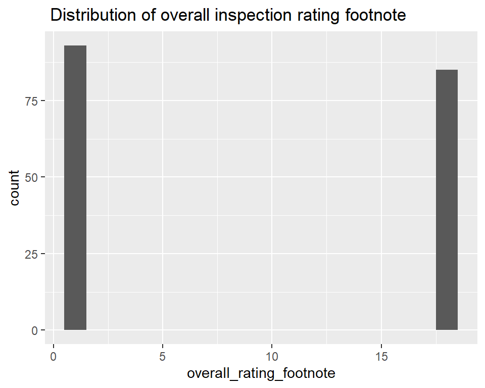

```r
ggplot(data= data_staffing_num)+
  geom_histogram(mapping = aes(x=overall_rating_footnote),binwidth=1,na.rm=TRUE)+ggtitle(" Distribution of overall inspection rating footnote ")
```

Discrete points are present and values are scaterred evenly.Bi-variate analysis can be done to further understand attributes impact.

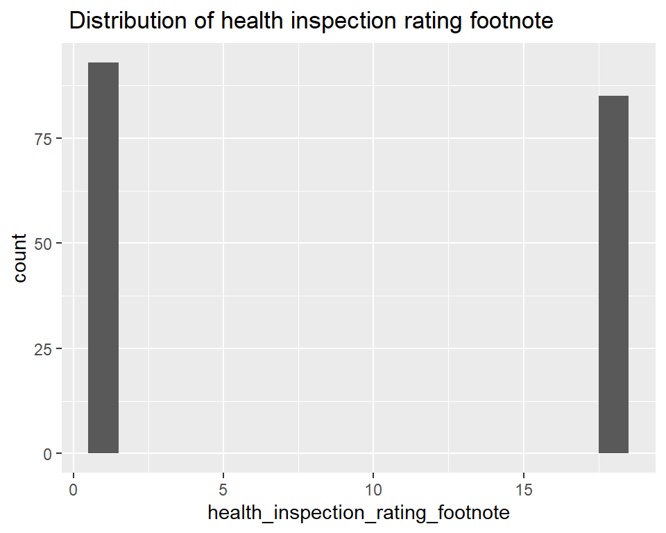

```r
ggplot(data= data_staffing_num)+
  geom_histogram(mapping = aes(x=health_inspection_rating_footnote),binwidth=1,na.rm=TRUE)+ggtitle(" Distribution of health inspection rating footnote ")
```

Discrete points are present and values are scattered evenly.Bi-variate analysis can be done to further understand attributes impact.

# Categorical Variable analysis

There are no missing data in categorical variables.

```r
data_staffing_char <- data_staffing %>% dplyr::select(where(is.character))

data_staffing_char %>%
  summarise_all(list(~sum(is.na(.))))
```

```
## # A tibble: 1 × 3
##   federal_provider_number provider_name provider_state
##                     <int>         <int>          <int>
## 1                       0             0              0
```

```r
  data_staffing_char %>% summarise(across(c(provider_name,provider_state,federal_provider_number),n_distinct))
```

```
## # A tibble: 1 × 3
##   provider_name provider_state federal_provider_number
##           <int>          <int>                   <int>
## 1         15172             53                   15446
```

Based on above values. We can consider provider_state for grouping as it has the least number of unique values and other attributes are text data which can be used for unique identification.

```r
  data_staffing_char %>% count(provider_state)
```

```
## # A tibble: 53 × 2
##    provider_state     n
##    <chr>          <int>
##  1 AK                19
##  2 AL               228
##  3 AR               225
##  4 AZ               146
##  5 CA              1193
##  6 CO               226
##  7 CT               215
##  8 DC                18
##  9 DE                46
## 10 FL               701
## # … with 43 more rows
```

We can observe not all the states have equal number of data points. We can actually ignore states AK,DC,DE as the data points are very less to identify any significant trend of the state.

## Standard Deviation Calculation numerical data types

```r
  sd_ignore_na <- function(x){

  sd(x,na.rm=TRUE)
}

data_staffing %>% dplyr::select(where(is.numeric)) %>% summarise(across(c(overall_rating_footnote,health_inspection_rating_footnote,total_number_of_penalties,number_of_residents_in_certified_beds,number_of_certified_beds,number_of_certified_beds,health_inspection_rating,number_of_payment_denials,qm_rating,overall_rating),sd_ignore_na))
```

```
## # A tibble: 1 × 9
##   overall_rati…¹ healt…² total…³ numbe…⁴ numbe…⁵ healt…⁶ numbe…⁷ qm_ra…⁸ overa…⁹
##            <dbl>   <dbl>   <dbl>   <dbl>   <dbl>   <dbl>   <dbl>   <dbl>   <dbl>
## 1           8.52    8.52    1.00    52.7    60.7    1.28   0.367    1.25    1.42
## # … with abbreviated variable names ¹overall_rating_footnote,
## #   ²health_inspection_rating_footnote, ³total_number_of_penalties,
## #   ⁴number_of_residents_in_certified_beds, ⁵number_of_certified_beds,
## #   ⁶health_inspection_rating, ⁷number_of_payment_denials, ⁸qm_rating,
## #   ⁹overall_rating
```

We can observe Standard deviation of different attributes are having different magnitude based on the data collection. Some of the attributes have standard deviation comparable to their mean.

## Question for Hypothesis Testing

1. Average(Mean) of the number_of_certified_beds of Nursing home with overall rating above 3 and below or equal to 3 is equal?
2. Standard deviation of the number_of_residents_in_certified_beds are of Nursing home with health inspection rating above 3 and below or equal to 3 is equal?

#### Question 1

In following code the data has been dived into two data set based on overall_rating being above 3 or not.Then hypothesis Test has been done on the means of number of certified beds,Such the the two data set have equal means.

NUll Hypothesis H[0] : Mean(Number of certified beds of Nursing homes with overall Rating above 3) == Mean(Number of certified beds of of Nursing homes with overall Rating equal to or below 3)

Alternate Hypothesis H[1] : Mean(Number of certified beds of Nursing homes with overall Rating above 3) not = Mean(Number of certified beds of of Nursing homes with overall Rating equal to or below 3)

```r
(data_staffing_test <- data_staffing%>% rowwise() %>% mutate(overall_rating_above_3 =overall_rating > 3))
```

```
## # A tibble: 15,446 × 16
## # Rowwise:
##    federal_pro…¹ provi…² provi…³ provi…⁴ provi…⁵ provi…⁶ numbe…⁷ numbe…⁸ overa…⁹
##    <chr>         <chr>   <chr>     <int>   <dbl>   <int>   <int>   <dbl>   <int>
##  1 015407        HEALTH… AL        35953  2.06e9     570      53    45         3
##  2 035297        SURPRI… AZ        85374  6.24e9      60     100    NA        NA
##  3 065264        WALBRI… CO        81641  9.71e9     510      30    27.5       3
##  4 075322        ESSEX … CT         6426  8.61e9      30      45    40.4       5
##  5 075346        ROSE H… CT         6759  8.61e9      20      25    NA         2
##  6 105393        BEAR C… FL        34667  7.28e9     500     120   108.        5
##  7 105677        NURSIN… FL        33612  8.14e9     280     120    NA         1
##  8 115404        LUMBER… GA        31549  9.12e9     884      86    71.8       3
##  9 115533        PRUITT… GA        30401  4.78e9     440     103    75         5
## 10 115681        PRUITT… GA        30434  4.79e9     620     143   123.        3
## # … with 15,436 more rows, 7 more variables: health_inspection_rating <int>,
## #   qm_rating <int>, number_of_payment_denials <int>,
## #   total_number_of_penalties <int>, overall_rating_footnote <int>,
## #   health_inspection_rating_footnote <int>, overall_rating_above_3 <lgl>, and
## #   abbreviated variable names ¹federal_provider_number, ²provider_name,
## #   ³provider_state, ⁴provider_zip_code, ⁵provider_phone_number,
## #   ⁶provider_ssa_county, ⁷number_of_certified_beds, …
```

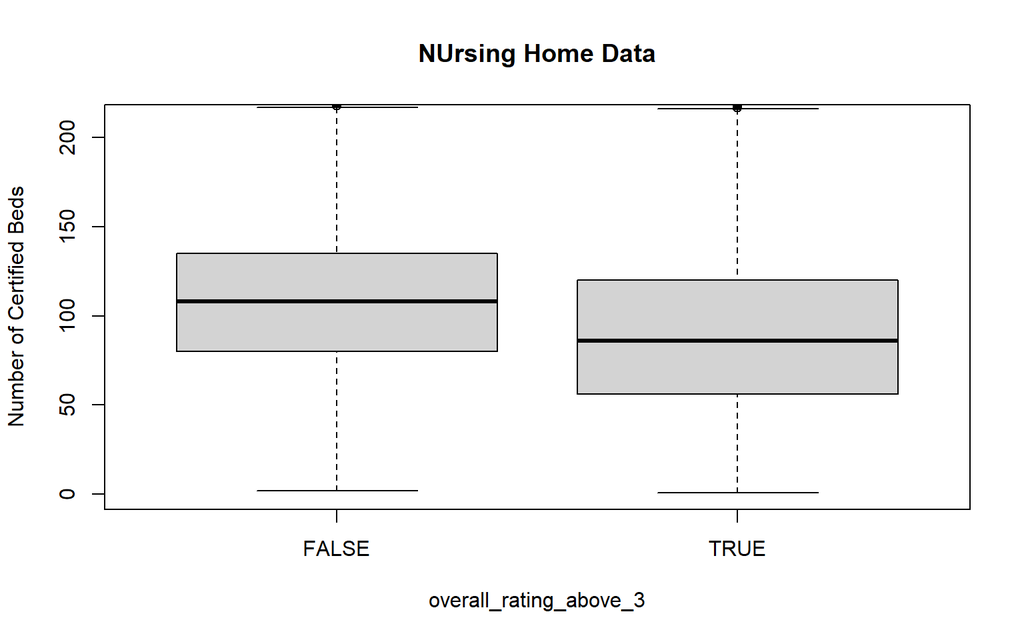

```r
boxplot(number_of_certified_beds~overall_rating_above_3,data=data_staffing_test, main="NUrsing Home Data",
   xlab="overall_rating_above_3", ylab="Number of Certified Beds",ylim=c(0,210))
```

Above box plot showcases the the distribution of number of certified beds in Nursing home with overall rating above 3 and overall rating equal to 3 or less than 3.

```r
data_staffing_o3 <- filter(data_staffing, overall_rating > 3)
data_staffing_b3 <- filter(data_staffing, overall_rating <= 3)

(mean(data_staffing_o3$number_of_certified_beds))
```

```
## [1] 94.83182
```

```r
(mean(data_staffing_b3$number_of_certified_beds))
```

```
## [1] 115.4501
```

```r
(var(data_staffing_o3$number_of_certified_beds,na.rm=TRUE))
```

```
## [1] 3712.554
```

```r
(var(data_staffing_b3$number_of_certified_beds,na.rm=TRUE))
```

```
## [1] 3489.432
```

```r
(t.test(data_staffing_o3$number_of_certified_beds,data_staffing_b3$number_of_certified_beds, alternative = "two.sided", var.equal = FALSE))
```

```
##
##  Welch Two Sample t-test
##
## data:  data_staffing_o3$number_of_certified_beds and data_staffing_b3$number_of_certified_beds
## t = -21.068, df = 14379, p-value < 2.2e-16
## alternative hypothesis: true difference in means is not equal to 0
## 95 percent confidence interval:
##  -22.53661 -18.69999
## sample estimates:
## mean of x mean of y
##  94.83182 115.45012
```

Based on the above hypothesis test we can understand there is definitely different distribution of number of certified beds with different means.We can not assume that the two distribution share same mean and both are not equal to each other based on the p-value, which is very less(2.2e-16).

We can infer number of certified beds distribution is different for Nursing homes having overall rating above 3 and Nursing homes having overall rating less than or equal to 3.

#### Question 2

In following code the data has been dived into two data set based on health_inspection_rating being above 3 or not.Then hypothesis Test has been done on the variance of number of number_of_residents_in_certified_beds,Such the the two data set have equal variance.

NUll Hypothesis H[0] : variance(number_of_residents_in_certified_beds of Nursing homes with health_inspection_rating above 3) == variance(number_of_residents_in_certified_beds of of Nursing homes with health_inspection_rating equal to or below 3)

Alternate Hypothesis H[1] :variance(number_of_residents_in_certified_beds of Nursing homes with health_inspection_rating above 3 not = variance(number_of_residents_in_certified_beds of of Nursing homes with health_inspection_rating equal to or below 3)

```r
(data_staffing_test2 <- data_staffing%>% rowwise() %>% mutate(health_inspection_rating_above3 =health_inspection_rating > 3))
```

```
## # A tibble: 15,446 × 16
## # Rowwise:
##    federal_pro…¹ provi…² provi…³ provi…⁴ provi…⁵ provi…⁶ numbe…⁷ numbe…⁸ overa…⁹
##    <chr>         <chr>   <chr>     <int>   <dbl>   <int>   <int>   <dbl>   <int>
##  1 015407        HEALTH… AL        35953  2.06e9     570      53    45         3
##  2 035297        SURPRI… AZ        85374  6.24e9      60     100    NA        NA
##  3 065264        WALBRI… CO        81641  9.71e9     510      30    27.5       3
##  4 075322        ESSEX … CT         6426  8.61e9      30      45    40.4       5
##  5 075346        ROSE H… CT         6759  8.61e9      20      25    NA         2
##  6 105393        BEAR C… FL        34667  7.28e9     500     120   108.        5
##  7 105677        NURSIN… FL        33612  8.14e9     280     120    NA         1
##  8 115404        LUMBER… GA        31549  9.12e9     884      86    71.8       3
##  9 115533        PRUITT… GA        30401  4.78e9     440     103    75         5
## 10 115681        PRUITT… GA        30434  4.79e9     620     143   123.        3
## # … with 15,436 more rows, 7 more variables: health_inspection_rating <int>,
## #   qm_rating <int>, number_of_payment_denials <int>,
## #   total_number_of_penalties <int>, overall_rating_footnote <int>,
## #   health_inspection_rating_footnote <int>,
## #   health_inspection_rating_above3 <lgl>, and abbreviated variable names
## #   ¹federal_provider_number, ²provider_name, ³provider_state,
## #   ⁴provider_zip_code, ⁵provider_phone_number, ⁶provider_ssa_county, …
```

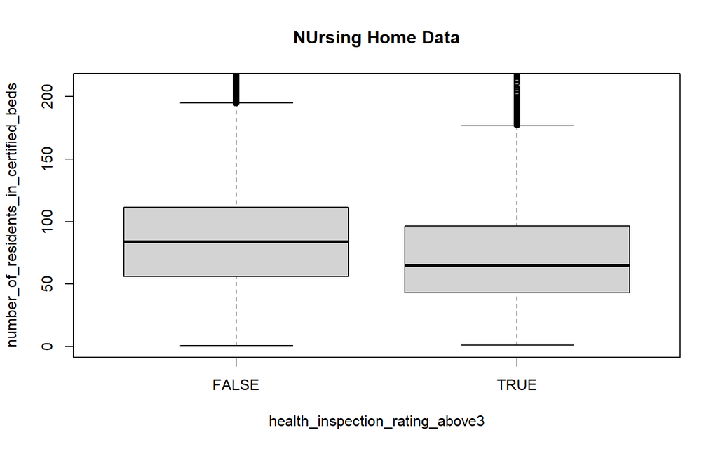

```r
boxplot(number_of_residents_in_certified_beds~health_inspection_rating_above3,data=data_staffing_test2, main="NUrsing Home Data",
   xlab="health_inspection_rating_above3", ylab="number_of_residents_in_certified_beds",ylim=c(0,210))
```

Above box plot showcases the the distribution of number_of_residents_in_certified_beds in Nursing homes with health inspection rating above 3 and health inspection rating equal to 3 or less than 3. Based on box plot distribution looks similar with intra quartile range of Nursing homes with health inspection rating above 3 slightly less than Nursing homes with health inspection rating equal to or below 3.

```r
data_staffing_oi3 <- filter(data_staffing, health_inspection_rating > 3)
data_staffing_bi3 <- filter(data_staffing, health_inspection_rating <= 3)

(var(data_staffing_oi3$number_of_residents_in_certified_beds,na.rm=TRUE))
```

```
## [1] 2486.86
```

```r
(var(data_staffing_bi3$number_of_residents_in_certified_beds,na.rm=TRUE))
```

```
## [1] 2841.578
```

```r
(var.test(data_staffing_oi3$number_of_residents_in_certified_beds,data_staffing_bi3$number_of_residents_in_certified_beds))
```

```
##
##  F test to compare two variances
##
## data:  data_staffing_oi3$number_of_residents_in_certified_beds and data_staffing_bi3$number_of_residents_in_certified_beds
## F = 0.87517, num df = 5125, denom df = 10107, p-value = 4.927e-08
## alternative hypothesis: true ratio of variances is not equal to 1
## 95 percent confidence interval:
##  0.834696 0.917947
## sample estimates:
## ratio of variances
##          0.8751684
```

We can infer number_of_residents_in_certified_beds is having different variance is different for Nursing homes having health_inspection_rating above 3 and Nursing homes having health_inspection_rating less than or equal to 3.

### Logistic Regression

Based on overall rating if we consider dividing Nursing Staff data into Good Overall rating as follows :-

1. 1 - with overall rating above 3 (Good )
2. 0 - with overall rating less than or equal to 3 (Not Good)

#### Base summary

```r
# Adding column based on other column:
data_staffing<-data_staffing %>%
  mutate(good_overall_rating = case_when(
    overall_rating > 3 ~ 1,
    overall_rating <= 3 ~ 0
    ))
(summary(data_staffing$good_overall_rating))
```

```
##    Min. 1st Qu.  Median    Mean 3rd Qu.    Max.    NA's
##  0.0000  0.0000  0.0000  0.4459  1.0000  1.0000     178
```

We can observe Mean is around 0.45 indicating more number of Nursing home data get rating is in range 0-3 and above 3 are also comparable its value is very close to 0.5 indicating close to equal amount of data point.

### Logistic Regression Implementation

In following code multiple logistic regression models were built to fit the data with following parameters:-

1. number_of_certified_beds
2. number_of_certified_beds + number_of_residents_in_certified_beds
3. number_of_certified_beds + total_number_of_penalties
4. total_number_of_penalties
5. health_inspection_rating
6. number_of_payment_denials

```r
data_staffing_num2 <- data_staffing %>% dplyr::select(where(is.numeric)) %>% select(!(provider_zip_code:provider_phone_number:provider_ssa_county))

(glm.fit1 <- glm(good_overall_rating ~ number_of_certified_beds, data = data_staffing_num2, family = "binomial"))
```

```
##
## Call:  glm(formula = good_overall_rating ~ number_of_certified_beds,
##     family = "binomial", data = data_staffing_num2)
##
## Coefficients:
##              (Intercept)  number_of_certified_beds
##                 0.487677                 -0.006784
##
## Degrees of Freedom: 15267 Total (i.e. Null);  15266 Residual
##   (178 observations deleted due to missingness)
## Null Deviance:       20990
## Residual Deviance: 20500     AIC: 20500
```

```r
(glm.fit2 <- glm(good_overall_rating ~ number_of_certified_beds+
                   number_of_residents_in_certified_beds, data = data_staffing_num2, family = "binomial"))
```

```
##
## Call:  glm(formula = good_overall_rating ~ number_of_certified_beds +
##     number_of_residents_in_certified_beds, family = "binomial",
##     data = data_staffing_num2)
##
## Coefficients:
##                           (Intercept)               number_of_certified_beds
##                               0.52608                               -0.01788
## number_of_residents_in_certified_beds
##                               0.01321
##
## Degrees of Freedom: 15233 Total (i.e. Null);  15231 Residual
##   (212 observations deleted due to missingness)
## Null Deviance:       20940
## Residual Deviance: 20280     AIC: 20280
```

```r
(glm.fit3 <- glm(good_overall_rating ~ number_of_certified_beds+
                   total_number_of_penalties, data = data_staffing_num2, family = "binomial"))
```

```
##
## Call:  glm(formula = good_overall_rating ~ number_of_certified_beds +
##     total_number_of_penalties, family = "binomial", data = data_staffing_num2)
##
## Coefficients:
##               (Intercept)   number_of_certified_beds
##                  0.812624                  -0.005596
## total_number_of_penalties
##                 -1.023056
##
## Degrees of Freedom: 15267 Total (i.e. Null);  15265 Residual
##   (178 observations deleted due to missingness)
## Null Deviance:       20990
## Residual Deviance: 18610     AIC: 18620
```

```r
(glm.fit4 <- glm(good_overall_rating ~ total_number_of_penalties, data = data_staffing_num2, family = "binomial"))
```

```
##
## Call:  glm(formula = good_overall_rating ~ total_number_of_penalties,
##     family = "binomial", data = data_staffing_num2)
##
## Coefficients:
##               (Intercept)  total_number_of_penalties
##                    0.2426                    -1.0519
##
## Degrees of Freedom: 15267 Total (i.e. Null);  15266 Residual
##   (178 observations deleted due to missingness)
## Null Deviance:       20990
## Residual Deviance: 18930     AIC: 18930
```

```r
(glm.fit5 <- glm(good_overall_rating ~ health_inspection_rating, data = data_staffing_num2, family = "binomial"))
```

```
##
## Call:  glm(formula = good_overall_rating ~ health_inspection_rating,
##     family = "binomial", data = data_staffing_num2)
##
## Coefficients:
##              (Intercept)  health_inspection_rating
##                   -7.147                     2.361
##
## Degrees of Freedom: 15267 Total (i.e. Null);  15266 Residual
##   (178 observations deleted due to missingness)
## Null Deviance:       20990
## Residual Deviance: 9509  AIC: 9513
```

```r
(glm.fit6 <- glm(good_overall_rating ~ qm_rating, data = data_staffing_num2, family = "binomial"))
```

```
##
## Call:  glm(formula = good_overall_rating ~ qm_rating, family = "binomial",
##     data = data_staffing_num2)
##
## Coefficients:
## (Intercept)    qm_rating
##     -3.2907       0.8218
##
## Degrees of Freedom: 15249 Total (i.e. Null);  15248 Residual
##   (196 observations deleted due to missingness)
## Null Deviance:       20960
## Residual Deviance: 17940     AIC: 17940
```

```r
(glm.fit7 <- glm(good_overall_rating ~ number_of_payment_denials, data = data_staffing_num2, family = "binomial"))
```

```
##
## Call:  glm(formula = good_overall_rating ~ number_of_payment_denials,
##     family = "binomial", data = data_staffing_num2)
##
## Coefficients:
##               (Intercept)  number_of_payment_denials
##                  -0.08266                   -1.97116
##
## Degrees of Freedom: 15267 Total (i.e. Null);  15266 Residual
##   (178 observations deleted due to missingness)
## Null Deviance:       20990
## Residual Deviance: 20120     AIC: 20130
```

```r
(glm.fit8 <- glm(good_overall_rating ~ number_of_payment_denials+health_inspection_rating+
                   number_of_certified_beds+number_of_residents_in_certified_beds, data = data_staffing_num2, family = "binomial"))
```

```
##
## Call:  glm(formula = good_overall_rating ~ number_of_payment_denials +
##     health_inspection_rating + number_of_certified_beds + number_of_residents_in_certified_beds,
##     family = "binomial", data = data_staffing_num2)
##
## Coefficients:
##                           (Intercept)              number_of_payment_denials
##                             -6.917994                              -0.476790
##              health_inspection_rating               number_of_certified_beds
##                              2.336932                              -0.007191
## number_of_residents_in_certified_beds
##                              0.007337
##
## Degrees of Freedom: 15233 Total (i.e. Null);  15229 Residual
##   (212 observations deleted due to missingness)
## Null Deviance:       20940
## Residual Deviance: 9418  AIC: 9428
```

## Summary of findings and questions for further analysis

1. We can observe skewness in the data set both positive and negative. Further bi variate analysis can give as more insight if there are any correlation among the variables.
2. Many ratings are given in the rating scale. We need to ascertain if the scale is ordinal or interval to further understand the parameter.Bivariate analysis can also give as relation between how the ratings differ based on location and other factors.
3. Some of the attributes have aggregated values in less than 3 value points. Need to understand can be consider them as binary variable.
4. We can actually create bins to segregate continuous data into categorical groups. Initial anaysis with width based binning are providing normal results. Further analysis with Frequency based and cluster based binning can be applied.
5. There is lot of information present in 15 variables which we further analyze with information that is stored in 70 variables which were not considered for initial analysis.
6. If go over Standard deviation of different attributes are having different magnitude based on the data collection. Some of the attributes have standard deviation comparable to their mean.
7. Based on hypothesis testing we came to know the number of beds is having different average value for Nursing home having overall rating above 3 and Nursing home having overall rating equal to 3 or less than 3.
8. Based on hypothesis testing we came to know the number of beds is having different average value for Nursing home having overall rating above 3 and Nursing home having overall rating equal to 3 or less than 3.
9. Based on hypothesis testing we came to know the number of residents in certified beds is having different different variance for Nursing home having health inspection rating above 3 and Nursing home having health inspection rating equal to 3 or less than 3.
10. Logistic regression models indicate we can predict good overall rating based on on predictor health inspection rating.So Nursing homes should consider improving the health regulation the most if they want better overall rating.

## References

This is a Analysis Document of Nursing Home Satffing Data set is prepared from the following link: [link](https://raw.githubusercontent.com/BuzzFeedNews/2020-04-cms-nursing-homes/master/data/staffing.csv)

Link of article: [link](https://www.buzzfeednews.com/article/mikesallah/coronavirus-nursing-home-inspections)

Book reffered: [link](https://r4ds.had.co.nz/exploratory-data-analysis.html#questions)